# An overview of the WOPR API backend for developers

#### Doug Leasure and Maksym Bondarenko

WorldPop Research Group  
University of Southampton

## Introduction

The WOPR REST API provides a way for web servers and other computers to communicate with the [WorldPop Open Population Repository](https://wopr.worldpop.org) to submit requests for data and to retrieve results. This can be used to:

1. Automate the process of downloading the latest WorldPop population data sets and documentation,
2. Submit spatial queries (points or polygons) to the WorldPop server to retrieve population estimates within user-defined geographic areas,
3. Get estimates of population sizes for specific demographic groups (i.e. age and sex), and
4. Get probabilistic estimates of uncertainty for all population estimates.

This document provides instructions how to utilize each of the following endpoints:

**Data Catalogue**  
https://wopr.worldpop.org/api/v1.0/data

**Spatial Queries**  
https://api.worldpop.org/v1/wopr/pointtotal  
https://api.worldpop.org/v1/wopr/pointagesex  
https://api.worldpop.org/v1/wopr/polytotal  
https://api.worldpop.org/v1/wopr/polyagesex

**Retrieve Results**  
[https://api.worldpop.org/v1/tasks/[task_id]](https://api.worldpop.org/v1/tasks/%5Btask_id%5D)

## Data Download

**API Endpoint:**  
https://wopr.worldpop.org/api/v1.0/data

This API endpoint will return the WOPR data catalogue in JSON format. The JSON is organized with the following hierarchical levels:

**country** A three letter code to identify the country that the dataset represents. WOPR uses [ISO country codes](https://en.wikipedia.org/wiki/ISO_3166-1_alpha-3) to abbreviate country names. For example `'NGA'` regers to Nigeria.  
**category** The category describes the types of data available for a given country. For example, `'Population'` refers to population estimates.  
**version** The version of a data release for a given country and data type. For example, `'v1.2'`.  
**file_type** The file_type describes the category of individual files. For example, `'gridded'` refers to gridded population estimates, and `'sql'` refers to the SQL database used on the WOPR backend to support the spatial queries described below.

Each file has the following attributes:

**title** is a short descriptive name of the data set.  
**desc** is a longer description of the data set.  
**citation** is the recommended citation.  
**doi** is the official published DOI (digital object identifier) that can be used for official citations. The DOI refers to a stable and permanent version of the file that is stored at ftp://ftp.worldpop.org/repo/wopr. These files may differ slightly from the files stored in the [WorldPop Open Population Repository](https://wopr.worldpop.org) if minor changes were made since the time of the DOI publication.  
**file** is the file name.  
**file_size** is the size of the file on the hard disk (MB).  
**url** is the URL for downloading the file.  
**date** is the date the file was released.  
**hash** is the MD5 hash that can be used to compare files to ensure their contents are identical.  
**git** is the URL for the GitHub repository containing code that is relevant to the data set (e.g. the code used to create the data).

## Spatial Queries

Spatial queries can be submitted to WOPR as points or polygon locations in a GeoJSON format using several different WOPR API endpoints that will be described below. Spatial requests are supported for any data releases in the category `'Population'` that contain an SQL database `file_type='sql'` (see Data Download above).

Before describing the API endpoints, a note about the format of the results. WOPR will return population estimates for the queried location and demographic group as a JSON that contains a vector of numbers representing the population estimate for a given location: `122,88,108,119,98,92,98,101,121,103,127,122,103,118,...`. A histogram of these numbers will graphically illustrate the population estimate and its uncertainty as a probability distribution:

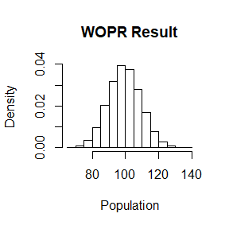

The most likely population estimate is the mean of this distribution (e.g. 100 people, in this case).

```r
summary(x)
```

```
##    Min. 1st Qu.  Median    Mean 3rd Qu.    Max.
##   65.00   93.00  100.00   99.83  106.00  140.00
```

The 95% confidence intervals for the population estimate can be calculated as the 0.025 and 0.975 quantiles:

```r
quantile(x, probs=c(0.025, 0.975))
```

```
##  2.5% 97.5%
##    81   120
```

### Point-based total population

**API Endpoint:**  
https://api.worldpop.org/v1/wopr/pointtotal

This endpoint accepts coordinates for a point location and returns the total population. Requests to this API endpoint require the following arguments:

**iso3** The [ISO country code](https://en.wikipedia.org/wiki/ISO_3166-1_alpha-3) of the country to query (e.g. `NGA`).  
**ver** The version of the population estimates to query (e.g. `1.2`).  
**lat** The latitude of the location to query using the WGS84 coordinate system (e.g. `11.53579`).  
**lon** The longitude of the location to query using the WGS84 coordinate system (e.g. `4.850808`).

An example of an API request: https://api.worldpop.org/v1/wopr/pointtotal?iso3=NGA&ver=1.2&lat=11.53579&lon=4.850808

This request returns a task identification number `2a6a2883-3fd7-5fbf-832c-86e5f35e7c5e` that can be used to query the result.

**API Endpoint:**  
https://api.worldpop.org/v1/tasks

An example of querying the result: https://api.worldpop.org/v1/tasks/2a6a2883-3fd7-5fbf-832c-86e5f35e7c5e

Results for any task id from WOPR can be retrieved in this way, regardless of the endpoint used to submit the request.

### Point-based population for specific age-sex group

**API Endpoint:**  
https://api.worldpop.org/v1/wopr/pointagesex

This endpoint accepts coordinates for a point location and returns the population size for a specified age-sex group. Requests to this API endpoint require the following arguments:

**iso3** The [ISO country code](https://en.wikipedia.org/wiki/ISO_3166-1_alpha-3) of the country to query (e.g. `NGA`).  
**ver** The version of the population estimates to query (e.g. `1.2`).  
**lat** The latitude of the location to query using the WGS84 coordinate system (e.g. `11.53579`).  
**lon** The longitude of the location to query using the WGS84 coordinate system (e.g. `4.850808`).  
**agesex** The age-sex groups for which a population estimate is required. This argument accepts a comma-separated vector of age-sex group identifiers. `f0` represents females less than one year old; `f1` represents females from age one to four; `f5` represents females from five to nine; `f10` represents females from 10 to 14; and so on. `m0` represents males less than one, etc. The full list of acceptable values: `m0, m1, m5, m10, m15, m20, m25, m30, m35, m40, m45, m50, m55, m60, m65, m70, m75, m80, f0, f1, f5, f10, f15, f20, f25, f30, f35, f40, f45, f50, f55, f60, f65, f70, f75, f80`.

An example of an API request: https://api.worldpop.org/v1/wopr/pointagesex?iso3=NGA&ver=1.2&lat=11.53579&lon=4.850808&agesex=m0,m1,f0,f1

This request will return the population of children under five at the specified point location. The task id was `38f18d6e-d7d8-5886-828a-45c29da7f766`. This result can be retrieved here:

https://api.worldpop.org/v1/tasks/38f18d6e-d7d8-5886-828a-45c29da7f766

### Polygon-based total population

**API Endpoint:**  
https://api.worldpop.org/v1/wopr/polytotal

This endpoint accepts a GeoJSON representing a polygon location and returns the total population. Requests to this API endpoint require the following arguments:

**iso3** The [ISO country code](https://en.wikipedia.org/wiki/ISO_3166-1_alpha-3) of the country to query (e.g. `NGA`).  
**ver** The version of the population estimates to query (e.g. `1.2`).  
**geojson** A GeoJSON representing the polygon location to query (see example below).

```
{
  "type": "FeatureCollection",
  "features": [
    {
      "type": "Feature",
      "properties": {},
      "geometry": {
        "type": "Polygon",
        "coordinates": [
          [
            [
              3.2080078125,
              7.0027636819827475
            ],
            [
              3.7902832031250004,
              7.0027636819827475
            ],
            [
              3.7902832031250004,
              7.612997502224103
            ],
            [
              3.2080078125,
              7.612997502224103
            ],
            [
              3.2080078125,
              7.0027636819827475
            ]
          ]
        ]
      }
    }
  ]
}
```

An example of an API request: https://api.worldpop.org/v1/wopr/polytotal?iso3=NGA&ver=1.2&geojson={“type”:“FeatureCollection”,“features”:[{“type”:“Feature”,“properties”:{},“geometry”:{“type”:“Polygon”,“coordinates”:[[[3.2080078125,7.0027636819827475],[3.7902832031250004,7.0027636819827475],[3.7902832031250004,7.612997502224103],[3.2080078125,7.612997502224103],[3.2080078125,7.0027636819827475]]]}}]}

This request returns a task identification number `06b50b9f-d94d-50b9-916a-1d34b767d00a` that can be used to query the result.

An example of querying the result: https://api.worldpop.org/v1/tasks/06b50b9f-d94d-50b9-916a-1d34b767d00a

**API Endpoint:**  
https://api.worldpop.org/v1/wopr/polyagesex

This endpoint accepts a GeoJSON representing a polygon location and returns the population size within a specified age-sex group. Requests to this API endpoint require the following arguments:

**iso3** The [ISO country code](https://en.wikipedia.org/wiki/ISO_3166-1_alpha-3) of the country to query (e.g. `NGA`).  
**ver** The version of the population estimates to query (e.g. `1.2`).  
**geojson** A GeoJSON representing the polygon location to query (see example above).  
**agesex** The age-sex groups for which a population estimate is required. This argument accepts a comma-separated vector of age-sex group identifiers. The full list of acceptable values: `m0, m1, m5, m10, m15, m20, m25, m30, m35, m40, m45, m50, m55, m60, m65, m70, m75, m80, f0, f1, f5, f10, f15, f20, f25, f30, f35, f40, f45, f50, f55, f60, f65, f70, f75, f80`.

An example of an API request: https://api.worldpop.org/v1/wopr/polyagesex?iso3=NGA&ver=1.2&agesex=m0,m1,f0,f1&geojson={“type”:“FeatureCollection”,“features”:[{“type”:“Feature”,“properties”:{},“geometry”:{“type”:“Polygon”,“coordinates”:[[[3.2080078125,7.0027636819827475],[3.7902832031250004,7.0027636819827475],[3.7902832031250004,7.612997502224103],[3.2080078125,7.612997502224103],[3.2080078125,7.0027636819827475]]]}}]}

This request returns a task identification number `b6418707-d795-56ef-9d06-c469e3697782` that can be used to query the result.

An example of querying the result: https://api.worldpop.org/v1/tasks/b6418707-d795-56ef-9d06-c469e3697782